# Machine Learning in clinical development

The what?, the why?, and (a bit of) the how?

Sandra Gonzalez Maldonado, Eliana Garcia Cossio, Antigoni Elefsinioti

2024-11-11

## Demo: Identification of predictive biomarkers with Virtual Twins

In this demo we will go through the process of identifying biomarkers that can predict treatment effect heterogeneity by analyzing simulated survival data.

### Disclaimer!:

1. In this tutorial, we use the entire dataset for training! This is for illustration purposes only. It exemplifies a one step of simulation study. ** Remember to split your data and validate your findings in the test set! **
2. No hyperparameter tuning is shown. (Hint: we could tune the number of trees, complexity parameters, etc.)

### Back to business ;)

The steps we will take are:

0. Load the dataset simulated in the previous demo
1. Virtual Twins Step 1a: Fit a RF to our data
2. Virtual Twins Step 1b: Predict counterfactual outcomes based on the fitted RF for all subjects
3. Virtual Twins Step 1c: Calculate the individual treatment effect (ITE)
4. Virtual Twins Step 2: Fit a classification and/or regression tree to the ITE
5. Check whether the predictive biomarkers were correctly identified!

# 0. Load simulated data from the previous demo

In the previous demo we simulated data with a right-censored survival outcome.

$Surv(time,status) \sim 0.3*bm01+0.6*bm02+0.4*bm03+0.1*bm04-trt-1.5*trt*bm01$ $-1.5*trt*bm05-1.5*trt*bm06 + noise(bm07...bm20)$

Where:

- Treatment effect $trt$
- Main effects of the biomarkers $0.3*bm01+0.6*bm02+0.4*bm03+0.1*bm04$
- Biomarker-treatment interactions $-1.5*trt*bm01-1.5*trt*bm05-1.5*trt*bm06$

We must keep in mind that some variables were removed from the dataset during pre-processing due to their high correlation:

- The variables bm01 and bm02 were highly correlated, so *bm01 was removed* and bm02 remained.
- The variables bm05 and bm06 were also highly correlated, so *bm06 was removed* and bm05 remained.

```r
#load utility packages
library(tidyverse)
library(here)
library(tidymodels)
library(randomForestSRC)
library(randomForest)
library(gridExtra)
```

```r
# 0. Loading the dataset simulated in the previous demo
load("C:/Users/gonsandr/OneDrive - Boehringer Ingelheim/Documents/TMCP stats advisor/The effective statistician workshop/Data/data_prep.Rdata")

data_prep <- as.data.frame(data_prep)
names(data_prep) <- c("id_number", names(data_prep[2:13]), "trt", "time", "status")

data_prep_train <- data_prep[!is.na(data_prep$id_number),]
data_prep_test  <- data_prep[is.na(data_prep$id_number),]

bm_names <- grep("bm", names(data_prep), value = T)
```

# VT Step 1a. Estimate individual treatment effect via Random Forest

In the original paper in which Virtual Twins was introduced (Foster et al., 2011) … the authors mention that learning a function for the outcome of interest can be done by either applying RF to the entire dataset (treatment and control together), or, alternatively, the function for the treated and control group can be learnt separately.

In a separate paper (Zhao et al, 2022; https://www.mdpi.com/1099-4300/24/7/975), the authors mention that the second option might be better:

> “Representation learning methods deal with the counterfactual problem, which divides the historical data of all the patients into two parts, one with data from for patients who have received treatment 𝑇=1 and another one for the control group 𝑇=0. In representation learning methods, instead of learning from the entire dataset, which encounters the counterfactual problem, the functions are learned separately, and for a new patient, the ITE can be predicted by as the difference in predicted outcomes between the treated and the control group.”

```r
 set.seed(123)

  data_trt0 <- base::subset(data_prep, trt == "control")
  data_trt1 <- base::subset(data_prep, trt == "active")

# 2. Fit a RF to our data
   # Fitting two RandomForest models

  rf_model_trt0 <- randomForestSRC::rfsrc(Surv(time, status) ~ .,
                                          data = data_trt0[,c("time", "status", bm_names)],
                                          nsplit = 0,
                                          ntree = 1000, importance = T)



  rf_model_trt1 <- randomForestSRC::rfsrc(Surv(time, status) ~ .,
                                          data = data_trt1[,c("time", "status", bm_names)],
                                          nsplit = 0,
                                          ntree = 1000, importance = T )
```

Show the variable importance from the two RF fits:

Variable importance from the RF fitted on data from the control group:

```r
print(round(sort(randomForestSRC::vimp(rf_model_trt0)$importance, T), 2))
```

```
## bm02 bm05 bm04 bm10 bm12 bm16 bm14 bm18 bm08 bm19 bm09 bm07
## 0.32 0.26 0.05 0.04 0.03 0.02 0.02 0.02 0.01 0.01 0.00 0.00
```

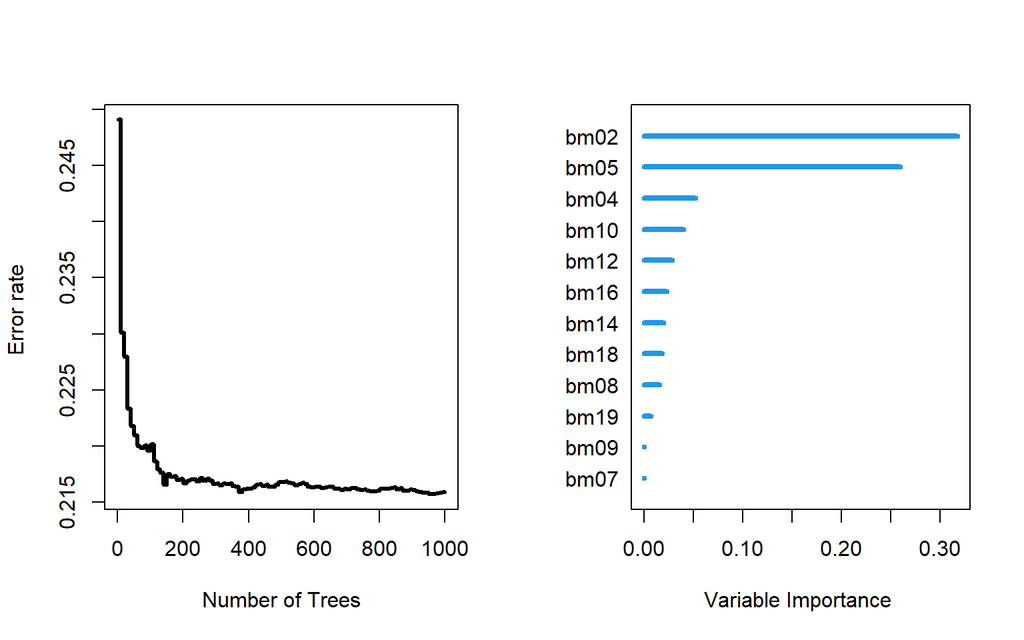

```
##
##        Importance   Relative Imp
## bm02       0.3173         1.0000
## bm05       0.2591         0.8164
## bm04       0.0517         0.1629
## bm10       0.0399         0.1258
## bm12       0.0281         0.0885
## bm16       0.0230         0.0724
## bm14       0.0193         0.0608
## bm18       0.0179         0.0565
## bm08       0.0153         0.0481
## bm19       0.0064         0.0202
## bm09       0.0003         0.0009
## bm07       0.0000         0.0001
```

```r
  randomForestSRC::plot.rfsrc(rf_model_trt0,
                              main = "Error rate and variable importance - control group")
```

Variable importance from the RF fitted on data from the active treatment group:

```r
  print(randomForestSRC::vimp(rf_model_trt1)$importance)
```

```
##         bm02         bm04         bm05         bm07         bm08         bm09
## 0.0241436561 0.1181738275 0.3453451141 0.0015380122 0.0117348744 0.0007270664
##         bm10         bm12         bm14         bm16         bm18         bm19
## 0.0175698402 0.0263351708 0.0368315378 0.0287399807 0.0602820790 0.0305979723
```

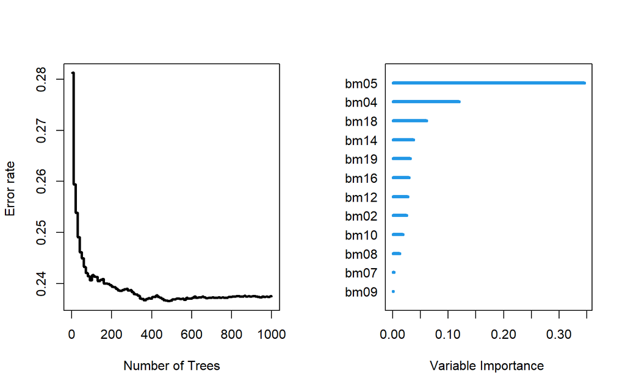

```
##
##        Importance   Relative Imp
## bm05       0.3459         1.0000
## bm04       0.1192         0.3446
## bm18       0.0610         0.1763
## bm14       0.0372         0.1075
## bm19       0.0314         0.0907
## bm16       0.0289         0.0836
## bm12       0.0273         0.0788
## bm02       0.0251         0.0725
## bm10       0.0182         0.0526
## bm08       0.0121         0.0351
## bm07       0.0017         0.0049
## bm09       0.0006         0.0018
```

```r
  randomForestSRC::plot.rfsrc(rf_model_trt1, ,
                              main = "Error rate and variable importance - active treatment group")
```

# VT Step 1b. Predict the outcome for all subjects with T=0 and T=1

For a survival outcome, we are interested in predicting survival times.

> If the actual treatment group for subject i is j , then the outcome is obtained from the out-of-bag estimate from the Random Forest, whereas the outcome for subjects in other treatment groups is obtained by applying the random forest to that person’s data, with the treatment group switched.

Alternatively, if two Random Forest models are fit separately for each treatment group:

> A variation of this step would be to use two separate random forests, one for each treatment group, and predict for each subject using the forest from the other group.

From the output of predict.rfsrc, we can extract:

- *chf*: the cumulative hazard function
- *survival*: the survival function
- *time.interest*: ordered unique death times
- *predicted*: … this one is a bit tricky. One would expect these to be the estimated survival times. Instead, it contains mortality estimates, defined by the authors of the package as:

> For survival, the prediction is *mortality* defined as the sum of the CHF over the event (death) times. This value represents estimated risk for each individual calibrated to the scale of the number of events. Thus as a specific example, if case $i$ has a mortality value of 100, then if all individuals had the same covariate as $i$, which is $X=x_i$, we would expect an average of 100 events.

To obtain estimated survival times, we need an intermediate step:

```r
# Sorted unique event times from the control and active treatment groups
times_0  <- randomForestSRC::predict.rfsrc(rf_model_trt0, data_prep)$time.interest
times_1  <- randomForestSRC::predict.rfsrc(rf_model_trt1, data_prep)$time.interest

# Estimated survival curves for the control and active treatment groups

Shat_0  <- randomForestSRC::predict.rfsrc(rf_model_trt0, data_prep)$survival
Shat_1  <- randomForestSRC::predict.rfsrc(rf_model_trt1, data_prep)$survival

expected_survival_time <- function(S.hat, unique_times) {
  grid.diff <- diff(c(0, unique_times, max(unique_times)))

  c(cbind(1, S.hat) %*% grid.diff)
}
```

```r
  twin0 <- expected_survival_time(Shat_0, times_0)
  twin1 <- expected_survival_time(Shat_1, times_1)
```

# VT Step 1c. Calculate the individual treatment effect

The individual treatment effect is defined as the difference in predicted survival times.

```r
  # Individual treatment effect
  z <- twin1 - twin0
```

Add estimates to the data

```r
  data_with_z <- cbind(data_prep, surv_time_control = twin0, surv_time_active = twin1, ITE = z)
```

# VT Step 2. Fit a classification and/or a regression tree to the individual treatment effect

## Classification tree

We define a new variable $Z^{*}$, $Z^{*}_i=1$ if $Z_i > c$ and $Z^{*}_i=0$ otherwise, where $c$ is a value for which the difference in treatment effect is considered meaningful. For example, it could be one of the quantiles of $Z$.

```r
(median_z <- quantile(z)["50%"])
```

```
##      50%
## 2.442056
```

```r
q_75_z   <- quantile(z)["75%"]


data_with_z$Z_cat_med <- ifelse(data_with_z$ITE > median_z, "1", "0")
data_with_z$Z_cat_q75 <- ifelse(data_with_z$ITE > q_75_z, "1", "0")
```

We use the function `rpart::rpart()` with the method = “class”

```r
tree.class <- rpart::rpart(Z_cat_med ~ ., data= data_with_z[,c("Z_cat_med", bm_names)],
                    method= "class",
                    maxdepth = 3,
                    cp=0,
                    maxcompete = 2)

print(tree.class)
```

```
## n= 1483
##
## node), split, n, loss, yval, (yprob)
##       * denotes terminal node
##
##  1) root 1483 741 0 (0.50033715 0.49966285)
##    2) bm05< 0.01667583 750  89 0 (0.88133333 0.11866667)
##      4) bm05< -0.246557 600  31 0 (0.94833333 0.05166667) *
##      5) bm05>=-0.246557 150  58 0 (0.61333333 0.38666667)
##       10) bm02< -0.1416586 74   1 0 (0.98648649 0.01351351) *
##       11) bm02>=-0.1416586 76  19 1 (0.25000000 0.75000000) *
##    3) bm05>=0.01667583 733  81 1 (0.11050477 0.88949523)
##      6) bm02< -0.6871181 153  62 1 (0.40522876 0.59477124)
##       12) bm05< 0.4507535 47   8 0 (0.82978723 0.17021277) *
##       13) bm05>=0.4507535 106  23 1 (0.21698113 0.78301887) *
##      7) bm02>=-0.6871181 580  19 1 (0.03275862 0.96724138) *
```

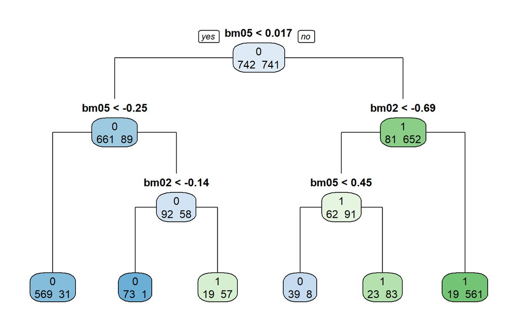

```r
library(rpart.plot)
rpart.plot::rpart.plot(tree.class,
                       type = 1,
                       extra = 1)
```